# AIA, XRT and NuSTAR data to calculate DEM for 12 Sep 2020 event

based on [this](https://github.com/ianan/axn_example/blob/main/axn_sep2020.ipynb) notebook by Iain Hannah

## Units

| Instrument | Data | Response function | Loci (Data/response) | DEM output units |
| --- | --- | --- | --- | --- |
| AIA | DN s$^{-1}$ px$^{-1}$ | DN s$^{-1}$ px$^{-1}$ cm$^5$ K$^{-1}$ | cm$^{-5}$ K$^{-1}$ | cm$^{-5}$ K$^{-1}$ |
| XRT | DN s$^{-1}$ px$^{-1}$ | DN s$^{-1}$ px$^{-1}$ cm$^5$ K$^{-1}$ | cm$^{-5}$ K$^{-1}$ | cm$^{-5}$ K$^{-1}$ |
| NuSTAR | counts s$^{-1}$ | counts s$^{-1}$ cm$^3$ K$^{-1}$ | cm$^{-3}$ K$^{-1}$ | cm$^{-5}$ K$^{-1}$ |
| NuSTAR response*area | counts s$^{-1}$ | counts s$^{-1}$ cm$^5$ K$^{-1}$ | cm$^{-5}$ K$^{-1}$ | cm$^{-5}$ K$^{-1}$ |

AIA processed in IDL with aia_prep, /normalize

Area in cm$^2$ determined from AIA images

XRT processed in IDL with xrt_prep, then adjusted for exposure here

XRT was summed on board by 16 pixels! So to get the true per-pixel values, divide the XRT-prepped data by 16

NuSTAR data 20s cadence images, adjusted such that pixel values are counts/s

# Response Functions

```python
trmatrix2=np.zeros((len(aia_tresp_logt),9))
trmatrix2[:,:6]=aia_trmatrix
trmatrix2[:,6]=xtrint
trmatrix2[:,7]=nstrint_lo
trmatrix2[:,8]=nstrint_hi
og_trmatrix=trmatrix2
pickle.dump(og_trmatrix,open('aia_xrt_nustar_trmatrix_091220.p','wb'))
```

```python
trmatrix2=np.zeros((len(aia_tresp_logt),9))
trmatrix2[:,:6]=aia_trmatrix
trmatrix2[:,6]=xtrint
trmatrix2[:,7]=nstrint_lo*area #run cells in Data section first
trmatrix2[:,8]=nstrint_hi*area
full_trmatrix=trmatrix2
```

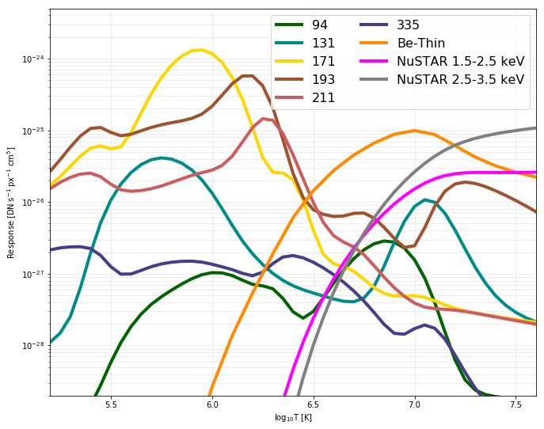

# Load data

## XRT

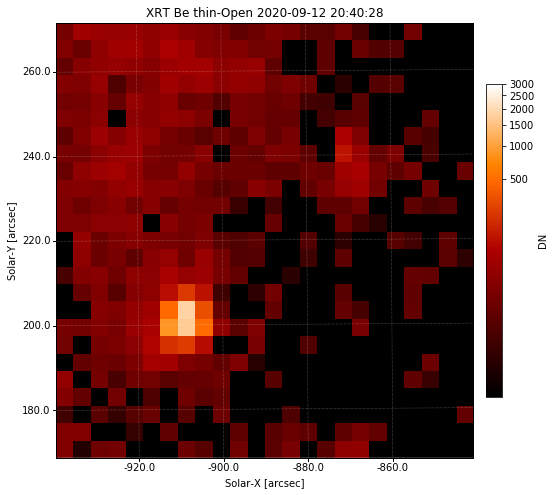

**select 10"x10" submap. Because of pixel size and source location, this ends up as >10" x ~ 10" or 3x2 px**

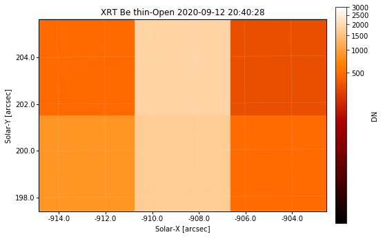

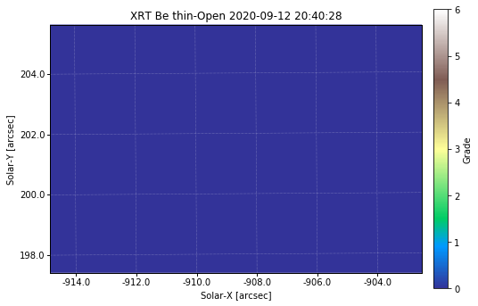